## [Consciousness and Cognition](https://www.sciencedirect.com/journal/consciousness-and-cognition)

[Volume 19, Issue 2](https://www.sciencedirect.com/journal/consciousness-and-cognition/vol/19/issue/2), June 2010, Pages 597-605

# Mindfulness meditation improves cognition: Evidence of brief mental training☆

https://doi.org/10.1016/j.concog.2010.03.014[Get rights and content](https://s100.copyright.com/AppDispatchServlet?publisherName=ELS&contentID=S1053810010000681&orderBeanReset=true)

Full text access

Abstract

Although research has found that long-term mindfulness meditation practice promotes executive functioning and the ability to sustain attention, the effects of brief mindfulness meditation training have not been fully explored. We examined whether brief meditation training affects cognition and mood when compared to an active control group. After four sessions of either meditation training or listening to a recorded book, participants with no prior meditation experience were assessed with measures of mood, verbal fluency, visual coding, and working memory. Both interventions were effective at improving mood but only brief meditation training reduced fatigue, anxiety, and increased mindfulness. Moreover, brief mindfulness training significantly improved visuo-spatial processing, working memory, and executive functioning. Our findings suggest that 4 days of meditation training can enhance the ability to sustain attention; benefits that have previously been reported with long-term meditators.

## Keywords

Mindfulness

Meditation

Cognition

Working memory

Mood

Attention

Meta-awareness

## 1. Introduction

People who have undergone extensive meditation training have shown improvements on cognitive performance (Cahn & Polich, 2006) and mood (Davidson et al., 2003). Long-term meditation practice has been found to enhance attentional (Jha, Krompinger, & Baime, 2007) and visuospatial processes (Kozhevnikov, Louchakova, Josipovic, & Motes, 2009). For example, 3-months of intensive meditation training (10–12 h/day) improved the ability to sustain attention during a dichotic listening task as evidenced by faster reaction times in response to a deviant tone, and reduced attentional blink responses when compared to controls (Lutz et al., 2009, Slagter et al., 2009; respectively). Moore and Malinowski (2009) found that self-reported mindfulness was positively correlated with sustained attention in experienced Buddhist meditation practitioners, when compared to controls. Additionally, long-term meditation practice has been found to reduce attentional blink in older adults when compared to age-matched and younger adults (van Leeuwen, Muller, & Melloni, 2009). In a study employing neuroimaging (Short et al., 2007), extensive meditation training heightened activation in executive attention networks that was correlated with improvements in sustained attention and error monitoring. These findings provide growing evidence of mindfulness meditation’s (MM) promotion of higher-order cognitive processing; specifically facets of conflict monitoring and cognitive control processes.

Mindfulness Based Stress Reduction (MBSR) programs, which are usually 8 weeks in duration and combine mindfulness meditation and gentle yoga, have been found to improve mood and affective processes (Nyklícek & Kuijpers, 2008); and are associated with improvements in immune system functioning (Davidson et al., 2003), stress (Carlson, Speca, Faris, & Patel, 2007), and emotional regulation (Nielsen & Kaszniak, 2006). MBSR programs are based on teaching participants to react non-judgmentally to stressful events by focusing on automatic and dynamic stimuli (breath; body; eating; walking). As participants cultivate these skills, top-down control processes regulate affective appraisals that lead to a reduction in stress responses (Grossman, Niemann, Schmidt, & Walach, 2004). In an elegant study, a MBSR program promoted decreases in stress ratings which were correlated with reductions in amygdala gray matter density; providing objective evidence for the positive effects of MBSR on stress (Hölzel et al., 2009).

Although advantageous to well-being, MBSR programs require extensive time and financial commitment. Consequently, most individuals do not have the time or resources to participate in extensive meditation interventions and few will choose the monastic lifestyle that is often associated with Buddhist contemplatives. Studying adept meditators is invaluable to understanding the aptitude of human consciousness, however, it is important to investigate whether briefer formats of mental training can provide some of the benefits that result from longer interventions.

MM is a mental practice based on focusing on the sensations of the breath/body while maintaining a relaxed state of mind. During formal meditation practice, distractions will arise and the meditator is taught to acknowledge discursive thoughts, and non-judgmentally return his/her attention back to their breathing (Wallace, 2006). Mindfulness training cultivates moment-to-moment awareness of the self and environment (Wallace, 2006). To this extent, mindfulness training heightens meta-cognitive processing (Austin, 1998). Meta-cognition is the conscious awareness of cognitive control processes (Fernandez-Duque, Baird, & Posner, 2000). Improvements in meta-cognition are related to the ability to restrict bottom-up processing of exogenously/endogenously driven, task-irrelevant information (Posner & Rothbart, 1998). Extensive training in mindfulness has been found to improve alerting and conflict monitoring Cahn and Polich, 2006, Jha et al., 2007), therefore mindfulness meditation training can hypothetically enhance meta-awareness. This process improves attention sustainability by teaching subjects to “release” cognitive appraisals of irrelevant information. So far, however, the cognitive benefits associated with mindfulness have been limited to studies examining adept meditators (Cahn & Polich, 2006).

Although research examining the effects of extensive meditation interventions is growing, the effects of brief mental training on mood and cognition are relatively unknown. We examined whether 4 days (20 min/day) of MM training affects behavioral markers of cognition and mood. Tang et al. (2007) reported that 5 days of Integrative Body Mind Training improved mood and cognitive processes. However, Integrative Body Mind Training incorporates various techniques (e.g. mindfulness, guided-imagery, music therapy) leaving it hard to decipher if mindfulness was the mechanism underlying improvements. A recent study (Zeidan, Gordon, & Goolkasian, 2009) found that 3 days of MM training was effective at reducing pain ratings and sensitivity, as well as anxiety scores when compared to baseline and other cognitive manipulations, such as relaxation and a math distracter task. A similar training regimen improved mood and reduced heart rate when compared to a sham MM and control group (Zeidan, Johnson, Gordon, & Goolkasian, in press).

The present study builds on our previous work by examining if the effects of brief meditation training can be found on cognitive tasks with varying demands on working memory, sustained attention, visual coding, and verbal fluency. We used the Symbol Digit Modalities Test and the n-back task to measure working memory, processing speed, and executive attention; the forward and backward digit span to measure immediate attention span, and the Controlled Oral Word Association Test to measure verbal fluency. Based on prior research (Cahn & Polich, 2006), we expected that these tasks would be the most sensitive to the effects of meditation. We also expected that brief MM training, when compared to a group that listened to a book recording, would promote positive mood, as measured by the Center for Epidemiologic Studies Depression scale (CES-D), State Anxiety Inventory, and the Profile of Mood States.

## 2. Methods

### 2.1. Participants

Sixty-three University of North Carolina, Charlotte students volunteered for the experiment in fulfillment of General Psychology requirements. The participants were recruited from those who were interested in learning meditation and who had no prior meditation experience. The consent form explained that subjects would be randomly assigned to a meditation or a book listening group. Group assignment depended upon the week that the participant signed up for the study. Seven participants from each of the groups did not complete the protocol and their data were not included. From the remaining participants, 24 were assigned to the meditation group and 25 to the control. Table 1 compares the groups on demographic (age; gender; ethnicity) and baseline measures and shows that there were no differences. The median age was 20 years. Sixty-one percent of the participants were White, 25% were African–American, 2% were Asian, and 4% were biracial, Native American, and Hispanic.

Table 1. Mean (SD) scores for each group on baseline measures.

| Empty Cell | Meditation | Controls | *t*/*χ*<sup>2</sup><sup>⁎</sup> | *P* |
| --- | --- | --- | --- | --- |
| Age | 22 (7.90) | 23 (8.36) | .66 | .51 |
| Caucasian | 67% | 56% | 7.12<sup>∗</sup> | .21 |
| Female | 63% | 56% | .21<sup>∗</sup> | .64 |
| *Self-report measures* |  |  |  |  |
| Freiburg Mindfulness Inventory | 43.33 (8.57) | 47.00 (8.24) | 1.53 | .13 |
| State Anxiety Inventory | 36.75 (10.72) | 35.28 (9.59) | .51 | .61 |
| POMS | 15.21 (26.39) | 12.00 (27.49) | .42 | .68 |
| CES-D | 15.21 (7.82) | 13.08 (10.13) | .81 | .42 |
| *Cognitive measures* |  |  |  |  |
| SDMT | 58.79 (10.78) | 59.52 (10.51) | .24 | .81 |
| Forward digit span | 10.88 (2.58) | 10.84 (2.15) | .05 | .96 |
| Backward digit span | 6.58 (2.60) | 6.72 (1.99) | .21 | .84 |
| COWAT | 35.92 (8.61) | 36.72 (9.74) | .31 | .76 |
| Extended hit rate | 2.38 (3.41) | 3.48 (4.58) | 1.33 | .19 |
| Accuracy proportion | .70 (.07) | .68 (.13) | .73 | .47 |
| Processing speed<sup>a</sup> | 130.03 (139.76) | 104.74 (116.74) | .63 | .53 |

*df* = 1,47*.* (*SD*) Standard deviations are given in parentheses. POMS (*Total Profile Mood State*)*.* CES-D (*Center for Epidemoplogic Studies Depression Scale*), SDMT (*Symbol Digit Modalities Test*), COWAT (*Controlled Oral Word Association*).

**a**

Processing speed measured in seconds.

**⁎**

*p* < .05.

### 2.2. Interventions

#### 2.2.1. Mindfulness meditation

Mindfulness training was modeled on basic Shamatha skills (Wallace, 2006). Meditation training was conducted by a facilitator with 10 years experience in teaching MM. In session one, small groups of three to five participants were instructed to relax, with their eyes closed, and to simply focus on the flow of their breath occurring at tip of their nose. If a random thought arose, they were told to passively notice and acknowledge the thought and to simply let “it” go, by bringing the attention back to the sensations of the breath. In subsequent sessions (2–4), participants worked on developing mindfulness skills. For example, in sessions 2 and 3, subjects were taught to focus on the full breath, that is, to focus on the sensations of the breath from the nostrils to the abdomen and back. Participants were also taught to notice and focus on any sensations that arose in the body, and to simply acknowledge those feelings and then to return their attention back to their breath (Wallace, 2006). Session 4 was premised on developing the skills established in the previous sessions, however, more time was spent in silence so that participants could meditate. As a manipulation check, each subject was asked after each meditation session, “Did you feel that you were truly meditating?” Across all sessions, participants were consistent in acknowledging that they were truly meditating.

#### 2.2.2. Control group

Control participants were instructed to listen in small groups to JRR Tolkein’s *The Hobbit* on compact disc (BBC audiobooks Ltd., 1997). The beginning of the story was played in session 1 and the following sessions (2–4) continued with the story. They were instructed to silence cell phones and any electronics, sit quietly and listen to the audio book. A research assistant sat with the participants to monitor attentiveness during the listening task.

## 3. Materials

### 3.1. Self-report measures

We administered the Freiburg Mindfulness Inventory, State Anxiety Inventory, CES-D, and Profile of Mood States on session 1 before the interventions and on session 4 after the interventions. The Profile of Mood States (McNair, Loor, & Droppleman, 1971) is a 65-item inventory that measures current mood state by rating adjective like statements (e.g. I feel calm) on a Likert scale (0–4). It consists of six subscales: tension, depression, confusion, fatigue, anger, and vigor: and a total negative mood score is calculated by subtracting the vigor scale from the sum of the remaining subscales.

The CES-D (Radloff, 1997) is a well-validated, 20-item, scale that measures depressive symptomatology. Subjects were asked to rate statements, based on the “last week,” such as “I felt happy” and “I felt depressed” on a four point Likert scale (0–3) and scores range from 0 to 60 with higher scores indicating higher levels of depression.

The Freiburg Mindfulness Inventory is a 14-item assessment that measures the experience of mindfulness (Walach, Buchheld, Buttenmuller, Kleinknecht, & Schmidt, 2006). It is a psychometrically valid instrument with high internal consistency (Cronbach alpha = . 93) (Baer, Smith, Hopkins, Krietemeyer, & Toney, 2007). Statements like “I am open to the experience of the present moment,” are rated on a four-point scale from 1 (rarely) to 4 (always). Scores range from 14 to 56 and higher scores indicate a greater degree of mindfulness. The Freiburg Mindfulness Inventory served as a manipulation check on participants’ ability to engage in a “mindful” state, and was also used to measure changes in mindfulness that resulted from the training.

The State Anxiety Inventory is a 20-item scale designed to measure state anxiety (Spielberger, 1983). It has high internal consistency with Cronbach’s alpha of .73 (Spielberger, 1983). Statements like “I feel worried,” are rated on a four-point scale from 1 (not at all) to 4 (very much so). Scores range from 20 to 80 and higher scores indicate higher levels of anxiety.

### 3.2. Cognitive measures

Standardized cognitive tasks, as well as a computer adaptive n-back task, were administered before (session 1) and after (session 4) the intervention. Alternate versions of all tasks (except the Symbol Digit Modalities Test) were used across sessions.

The Controlled Oral Word Association Test (Benton, 1989) is a measure of verbal fluency in which subjects are asked to say as many words as they can think of beginning with the letters “F, A, and S”, or “C, F, and L” within one minute. The dependent measure is the total number of words produced.

The Symbol Digit Modalities Test (Smith, 1982), written version, is a measure of complex visual tracking and working memory that requires decoding of a series of numbers listed on paper according to a corresponding template of visual symbols. With the use of a reference key, participants were given 90 s to accurately match numbers with corresponding geometric figures. The dependent measure is number of symbols coded minus errors.

The forward/backward digit span (Wechsler Adult Intelligence Scale-Revised (WAIS-R) (Wechsler, 1981) was used to measure immediate memory span. The dependent measures are total forward digit span and total backward digit span. In the forward digit span, subjects can correctly repeat back a span of up to16 digits. In the backward version, subjects can recite back a span of up to 14 digits backwards. Higher scores are indicative of higher memory recall.

The computer adaptive n-back task is an adaptive, accuracy selectable, 2-back task that consists of 54 trials and was developed in order to measure information processing speed, working memory and attention. It represents an advancement over previously used n-back tasks (as cited in Strauss, Sherman, & Spreen, 2006) because it corrects for the accuracy-speed confound by allowing the experimenter to set desired accuracy levels and by equating accuracy levels across groups. The program’s algorithms (V2ASQQQQ) variably adjust the presentation speed based on individual trial responses, response patterns and multiple accuracy windows to a value that supports the desired accuracy. Participants view a sequence of letters and indicate whether or not a probe letter is the “same” or “different” as the stimulus item presented two items back. The program computes two measures – speed of processing and “extended hit rate” (representing a run of correct responses). A measure of accuracy was also computed to make sure that there were functionally equivalent levels across groups.

## 4. Procedure

Participants were assigned to intervention groups based on the particular week that they enrolled in the experiment. Mindfulness meditation and control group interventions were randomly assigned to weeks. The interventions met on the same days of the week at the same time of day.

### 4.1. Session 1

After obtaining consent forms, participants completed the Freiburg Mindfulness Inventory, the Profile of Mood States, the State Anxiety Inventory, CES-D in random order followed by the Symbol Digit Modalities Test, backwards/forward digit span recall test, the Controlled Oral Word Association Test, and computer adaptive two-back task in random order. Based on group assignment, subjects were either led in meditation or listened to The Hobbit in a small group setting for 20 min in each session. Afterwards, the State Anxiety Inventory was reassessed.

### 4.2. Sessions 2–3

Depending on group assignment, participants either came in for meditation training or book listening, and the State Anxiety Inventory was completed before and after the meditation/listening intervention.

### 4.3. Session 4

Participants in the meditation and listening group completed the State Anxiety Inventory before their respective intervention. At the completion of the intervention, the Freiburg Mindfulness Inventory, State Anxiety Inventory, Profile of Mood States, CES-D, and the cognitive tasks were administered.

In general, the statistical analyses tested for the between group effect of intervention training and the within group effect of pre/post (session 1 vs. session 4) intervention training. The State Anxiety Inventory was administered before and after the intervention in each session. Multivariate analyses of variance (MANOVA) were used (with Wilk’s criterion as the test statistic) on the subscale scores of the Profile of Mood States, and the scores from the cognitive tasks (Symbol Digit Modalities Test, Fluency, Backward/Forward recall tests, extreme hit rate, and speed of processing). Follow-up univariate analyses were conducted when appropriate. Total Profile of Mood States, State Anxiety Inventory, CES-D, and Freiburg Mindfulness Inventory were analyzed with separate mixed analysis of variances (ANOVA). A significance level of .05 was used for all statistical tests.

## 5. Results

### 5.1. Self-report measures

Table 2 reports the Freiburg Mindfulness Inventory and Profile of Mood States data for each group across sessions. The analysis on the Freiburg Mindfulness Inventory scores showed that brief MM training was effective at increasing mindfulness skills when compared to controls. There was a group by session interaction, *F*(1, 47) = 5.73, *p* = .02, *η*<sup>2</sup> = .11, and an effect of session, *F*(1, 47) = 13.18, *p* = .001, *η*<sup>2</sup> = .22; but no effect of group, *F* < 1.

Table 2. Mean (*SD*) for each group on POMS and FMI.

| Empty Cell | Meditation<sup>a</sup> Pre | Meditation<sup>a</sup> Post | Control<sup>b</sup> Pre | Control<sup>b</sup> Post |
| --- | --- | --- | --- | --- |
| FMI | 43.33 (8.57) | 49.96 (10.0) | 47.00 (8.24) | 48.36 (8.42) |
| Total POMS | 15.20 (26.39) | −4.80 (15.63) | 12.00 (27.49) | −1.16 (11.78) |
| Tension | 8.50 (6.95) | 2.91 (2.75) | 6.28 (6.14) | 2.60 (2.22) |
| Depression | 6.13 (7.94) | 1.95 (3.99) | 4.52 (8.38) | .52 (1.16) |
| Anger | 4.00 (5.89) | 1.91 (2.88) | 3.80 (5.73) | 1.20 (1.98) |
| Vigor | 15.88 (5.49) | 14.04 (5.85) | 18.75 (7.17) | 15.16 (6.33) |
| Fatigue | 5.54 (4.33) | 1.71 (3.17) | 4.84 (5.32) | 4.80 (5.57) |
| Confusion | 6.92 (3.88) | 5.46 (3.56) | 6.60 (3.72) | 4.88 (2.20) |

Total (total mood score), (Freiburg Mindfulness Inventory).

**a**

*n* = 24.

**b**

*n* = 25.

The analysis on the total scores from the Profile of Mood States indicated a reduction in negative mood across session, *F*(1, 47) = 19.50, *η*<sup>2</sup> = .29; however, there were no group differences, *F* < 1, and group did not interact with session, *F* < 1. The MANOVA on the six subscales of the Profile of Mood States was similar in showing a session effect, *F*(6, 42) = 4.50, *p* = .001, *η*<sup>2</sup> = .39; and there was no main effect for group, *F*(6, 42) = 1.94, *p* = .10; but there was a marginally significant group by session interaction, *F*(6, 42) = 2.22 *p* = .06, *η*<sup>2</sup> = .24.

State Anxiety Inventory scores, presented in Table 3, were analyzed with a two (group) × two (before/after) × four (session) ANOVA. As expected, the anxiety scores dropped significantly after practice with meditation but not after listening to the book. The analysis indicated a before/after effect, *F*(1, 47) = 110.03, *p* < .001, *η*<sup>2</sup> = .70, and before/after interacted with group, *F*(1, 47) = 40.19, *p* < .001, *η*<sup>2</sup> = .46. There was also a decline in state anxiety scores across session, *F*(3, 141) = 6.85, *p* < .001, *η*<sup>2</sup> = .13. However, there were no other interactions; session did not interact with group, (*F* < 1), or in a three-way interaction with group, and before/after, *F*(3, 141) = 1.47, *p* = .23.

Table 3. Means (SD) for control and meditation group on State Anxiety Inventory scores across sessions.

| Empty Cell | Meditation<sup>a</sup> Before | Meditation<sup>a</sup> After | Control<sup>b</sup> Before | Control<sup>b</sup> After |
| --- | --- | --- | --- | --- |
| Session 1 | 36.75 (10.72) | 27.58 (5.76) | 35.28 (9.33) | 35.12 (10.51) |
| Session 2 | 33.75 (9.08) | 24.96 (5.34) | 30.48 (6.32) | 27.24 (5.91) |
| Session 3 | 32.67 (7.33) | 25.29 (4.15) | 31.68 (7.64) | 29.32 (7.83) |
| Session 4 | 32.29 (8.30) | 25.67 (5.28) | 30.40 (7.54) | 28.28 (6.17) |
| *M* (*SD*) | 33.86 (5.98) | 25.88 (3.67) | 31.96 (4.46) | 29.99 (5.53) |

**a**

*n* = 24.

**b**

*n* = 25*.*

The analysis of the CES-D scores were similar to the Profile of Mood States subscale for depression in showing a significant decrease in depression scores from session 1(*M* = 14.12, *SD* = 10.08) to 4 (*M* = 9.28, *SD* = 5.13), *F*(1, 47) = 8.69, *p* = .005, *η*<sup>2</sup> = .16; but there were no effects of group and no interaction between session and group (*Fs* < 1).

### 5.2. Cognitive tasks

Fig. 1 shows that brief mindfulness training was effective at improving performance on several cognitive tasks—Symbol Digit Modalities Test, verbal fluency, and the n-back task. The MANOVA on the scores from the Symbol Digit Modalities Test, verbal fluency, the forward and backward digit span, and the two measures of the n-back task showed a significant group by session interaction, *F*(6, 42) = 2.28, *p* = .05, *η*<sup>2</sup> = .25; a main effect of session, *F*(6, 42) = 10.66, *p* < .001, *η*<sup>2</sup> = .60; and no effect of group, *F* < 1.

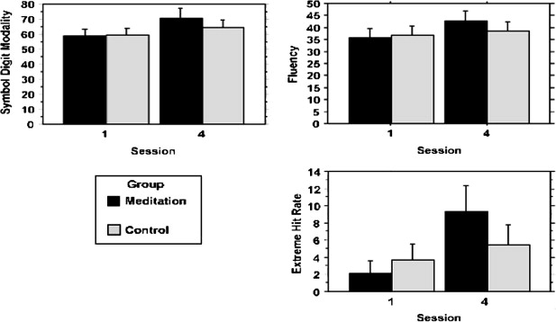

1. [Download: Download full-size image](https://ars.els-cdn.com/content/image/1-s2.0-S1053810010000681-gr1.jpg)

Fig. 1. Mean scores for the group by session interaction from the Symbol Digit Modalities test, Controlled Oral Word Association Test, and the Computer Adaptive 2-back task. Error bars represent 95% confidence intervals.

Follow-up ANOVAs on symbol digit modality and verbal fluency showed a significant improvement in performance across sessions for the meditation group but not for the control group. The two analyses showed significant interaction effects: Symbol Digit Modalities Test, *F*(1, 47) = 6.78, *p* = .01, *η*<sup>2</sup> = .13, verbal fluency, *F*(1, 47) = 5.27, *p* = .03, *η*<sup>2</sup> = .10, and main effects of session, Symbol Digit Modalities Test, *F*(1, 47) = 18.78, *p* < .001, *η*<sup>2</sup> = .29 and verbal fluency, *F*(1, 47) = 12.45, *p* = .001, *η*<sup>2</sup> = .21.

The ANOVA on the accuracy measure from the computer adaptive 2-back task found no differences across sessions or between groups (*Fs* < 1), indicating that the 2-back task was performed at the same level of accuracy across the two conditions.

Fig. 1 shows the significant group by session interaction found in the analysis on the extended hit rate from the computer adapted n-back task, *F*(1, 47) = 6.76, *p* = .01, *η*<sup>2</sup> = .12. The meditation group, in contrast to the control group, had more extended hit runs. There was also a significant session effect, *F*(1, 47) = 18.78, *p* < .001, *η*<sup>2</sup> = .29. Follow-up analyses on the speed measure of the n-back task did not show any evidence of an interaction effect *F* < 1, or an effect of session or group, *F*s < 1.

## 6. Discussion

Our findings, with naïve participants learning mindfulness techniques by means of a brief training format, are consistent with those that have been reported for adept meditators. Four days (20 min/day) of MM training was effective in significantly increasing mindfulness scores in comparison to an active control group. Our brief MM training protocol promoted significant effects on several cognitive tasks that require sustained attention and executive processing efficiency (Symbol Digit Modalities Test, verbal fluency, and the hit runs on n-back task). However, no specific benefits from MM training were found with many of the mood scales, the forward and backward digit span or speed on the n-back task. It is important to note that the groups did not differ at baseline on any of the measures and had no prior meditative experience.

A previous study (Zeidan et al., in press) that examined brief MM training, found more pervasive mood changes when comparing MM to sham meditation and control interventions. In the current study, listening to the book was intended to occupy their attention and not expected to affect mood. However, it may have served as a relaxing activity, which could explain the decrease in negative mood after book listening. In a recent review examining the efficacy of mindfulness interventions, MBSR programs were not more effective than active control groups (e.g. relaxation; cognitive therapy) on mood outcomes, when compared to wait-listed groups (Toneatto & Nguyen, 2007).

There are a number of possible mechanisms that may explain the relation between mindfulness and cognitive improvement. In contrast to controls, brief MM training reduced participants’ fatigue and anxiety ratings. Fatigue and anxiety may be particularly critical in affecting information processing. More participants would be needed, however, to properly assess the relatedness among these measures.

Prior studies with multiple sclerosis patients have found that fatigue adversely affects complex visual tracking speed measured by the Symbol Digit Modalities Test, (Andreasen, Spliid, Andersen, & Jakobsen, 2009), 2-back task processing (Diamond, Johnson, Kaufman, & Graves, 2008), and sustained attention on the Paced Auditory Serial Addition Test (Schwid et al., 2003). In two experiments, researchers found that both threat induced and state anxiety disrupted spatial but not verbal working memory on a three item n-back task in healthy undergraduates (Shackman et al., 2006). Given the fact that fatigue is the hallmark symptom in chronic fatigue syndrome, in addition to impairments in attention (Johnson, DeLuca, Diamond, & Natelson, 1998) and information processing (DeLuca et al., 2004), interventions that reduce fatigue and anxiety and improve vigilance could also potentially enhance information processing efficiency.

MM is based on promoting a balance between a relaxed and vigilant state of mind (Wallace, 2006). The ability to self-regulate emotions has been found to be a key component in enhancing cognition (Austin, 1998, Moore and Malinowski, 2009). It is possible that the calming effects of MM combined with the increased capacity to focus on the present improved cognitive performance after brief training. MM training enhances present moment awareness by teaching participants to notice subtle distractions (feelings; thoughts; emotions) while repeatedly bringing attention back to the meditation object. This process can promote attentional stability (Epel et al., 2009, Wallace, 2006).

Some of these cognitive benefits have recently been reported with experienced meditators (Kozhevnikov et al., 2009). In fact, Brefczynski-Lewis and colleagues (2007) found that adept and novice meditators exhibited overlapping higher order attention-related neural activations. Similarly, 5 days of Integrative Body Mind Training effectively increased neural activity in the executive attention network which was correlated with better performance on attentional tasks (Tang et al., 2009) and twenty minutes of MM practice reduced habitual responding on the Stroop task (Wenk-Sormaz, 2005, Zeidan and Faust, 2008).

Research associated with the benefits of brief MM training is sparse, but available evidence suggests that the immediate effects MM are not only associated with improving mood, but also developing deeper cognitive processing skills, specifically reducing lapses of attention. There were no differences between groups on digit span and these tasks were not timed, and did not, therefore, tax subjects on speed of processing. However, one factor that links the cognitive tasks that were affected by MM intervention is that they required sustained attention to perform well. Therefore, it appears that a short-term benefit of MM training could be increasing the ability to focus on timed or speeded tasks.

Another explanation of why brief MM training improved cognition is associated with the ability to control the processing of self-referential thought. Some have provided evidence for overlapping networks between mindfulness, meta-awareness, executive functioning, and mind-wandering processes (Epel et al., 2009, Farb et al., 2007, Tang et al., 2007). Mind-wandering adversely affects cognitive performance by reducing supervision of goal-directed attention (Smallwood, McSpadden, & Schooler, 2007). When the mind wanders, discursive thoughts become the primary focus further decoupling attention directed towards the primary task (Smallwood & Schooler, 2006). This “automatic” process of mind-wandering suggests that there is a distinctive break in meta-awareness (Smallwood & Schooler, 2006). Meta-awareness is defined as the ability to reflect or be aware of ongoing thought or mental states (Epel et al., 2009, Smallwood et al., 2007). MM training is premised on teaching subjects to acknowledge discursive thoughts and to gently return their attention back to the meditation object. The immediate benefits of mindfulness meditation training may be associated with increasing the awareness of ongoing cognitive states, which improves attentional efficiency. As previously mentioned, the improvements in mood may have also improved information processing. Furthermore, recent findings suggest that improvements in mood may reduce mind-wandering (Smallwood, Fitzgerald, Miles, & Phillips, 2009). In contrast, negative mood can lead to rumination and further lapses in attention. We postulate that the meditation group’s improvements in mood may have contributed to reducing mind-wandering, evidenced by significant improvements on a spectrum of cognitive tasks and mindfulness scores.

Meta-awareness and executive functioning are independent but highly overlapping constructs (Fernandez-Duque et al., 2000). Although we did not directly test for this, the short-term benefits of mindfulness may promote reductions in reflexive, automatic processing of irrelevant information by improving attentional sustainability. Additionally, minimal training in mindfulness may be effective in promoting executive-level functioning in detecting when the mind has wandered (meta-awareness), further reducing lapses in attention. Mindfulness practice promotes a form of meta-cognitive insight (Ortner, Kilner, & Zelazo, 2007), where MM practitioners learn to emotionally disengage from distracters (frustration; anxiety) (Teasdale, 1999). This form of top-down cognitive control leads the MM practitioner to more readily focus on the present task leading to better performance. Our findings extend previous work by using sensitive multiple functional and cognitive measures (e.g. the accuracy-selectable adaptive n-back task) that provide converging lines of evidence supporting the positive effect of MM on tasks that tap deep cognitive processing.

Our findings apply to undergraduates and cannot be generalized to older adults, but show promise for positive effects on attentional tasks. Additionally, the improvements exhibited by the meditation group may be due to direct effects of just having meditated in session four. The Hobbit listening group was a more active control than prior control groups (e.g. sham mindfulness meditation) (Zeidan et al., in press), and may explain the lack of differences between groups on self-reported mood. However, the MM training group was significantly more effective at reducing anxiety and fatigue levels, when compared to the controls.

We do not suggest that brief mental training is as effective as extensive training regimens. It is well documented that consistent and extensive meditation training promotes lasting changes in cognition and well-being (Cahn & Polich, 2006). Our findings show that there are immediate, short-term benefits to practicing mindfulness meditation. These benefits may have clinical implications. For instance, if a meditative state can be experienced after a brief training regimen, then individuals may feel more inclined to continue practice, which can lead to better health outcomes (Grossman et al., 2004). Moreover, meditation practice may be more attractive and easily disseminated if it can be shown to be effective without extensive training. This is the first study to demonstrate that 4 days of MM training can promote benefits on a range of cognitive tasks. Ongoing studies are employing neuroimaging to understand if and how brief meditation training affects the brain and behavior.

## Acknowledgments

The authors would like to thank Susan Avett, Kari Young, Sasha Levons and Rachel Hinson for help with data collection and scoring.

## References

1. Andreasen et al., 2009

   A.K. Andreasen, P.E. Spliid, H. Andersen, J. Jakobsen

   Fatigue and processing speed are related in multiple sclerosis

   European Journal of Neurology (2009), 10.1111/j.1468-1331.2009.02776.x

   (Epub ahead of print)

   View at publisher

   Google Scholar
2. Austin, 1998

   J.H. Austin

   Zen and the brain: Toward an understanding of meditation and consciousness

   MIT Press, Cambridge, MA (1998)

   [Google Scholar](https://scholar.google.com/scholar_lookup?title=Zen%20and%20the%20brain%3A%20Toward%20an%20understanding%20of%20meditation%20and%20consciousness&publication_year=1998&author=J.H.%20Austin)
3. Baer et al., 2007

   R. Baer, G. Smith, J. Hopkins, J. Krietemeyer, L. Toney

   Using self report assessment methods to explore facets of mindfulness

   Assessment, 13 (2007), pp. 27-45, 10.1177/1073191105283504

   [View at publisher](https://doi.org/10.1515/9781685857349-005)Google Scholar
4. Benton, 1989

   A.L. Benton

   Multilingual aphasia examination

   AJA Associates, Iowa City, Iowa (1989)

   [Google Scholar](https://scholar.google.com/scholar_lookup?title=Multilingual%20aphasia%20examination&publication_year=1989&author=A.L.%20Benton)
5. Brefczynski-Lewis et al., 2007

   J.A. Brefczynski-Lewis, A. Lutz, H.S. Schaefer, D.B. Levinson, R.J. Davidson

   Neural correlates of attentional expertise in long-term meditation practitioners

   Proceedings of the National Academy of Sciences, 104 (27) (2007), pp. 11483-11488, 10.1073/pnas.0606552104

   [View at publisher](https://doi.org/10.1073/pnas.0606552104)[View in Scopus](https://www.scopus.com/inward/record.url?eid=2-s2.0-34547469373&partnerID=10&rel=R3.0.0)Google Scholar
6. Cahn and Polich, 2006

   B.R. Cahn, J. Polich

   Meditation states and traits: EEG, ERP, and neuroimaging studies

   Psychological Bulletin, 132 (2006), pp. 180-211, 10.1037/0033-2909.132.2.180

   [View at publisher](https://doi.org/10.1037/0033-2909.132.2.180)[View in Scopus](https://www.scopus.com/inward/record.url?eid=2-s2.0-33645111338&partnerID=10&rel=R3.0.0)[Google Scholar](https://scholar.google.com/scholar_lookup?title=Meditation%20states%20and%20traits%3A%20EEG%2C%20ERP%2C%20and%20neuroimaging%20studies&publication_year=2006&author=B.R.%20Cahn&author=J.%20Polich)
7. Carlson et al., 2007

   L.E. Carlson, M. Speca, P. Faris, K.D. Patel

   One year pre-post intervention follow-up of psychological, immune, endocrine and blood pressure outcomes of mindfulness-based stress reduction (MBSR) in breast and prostate cancer outpatients

   Brain Behavior and Immunity, 21 (8) (2007), pp. 1038-1049, 10.1016/j.bbi.2007.04.002

   [View PDF](https://www.sciencedirect.com/science/article/pii/S0889159107000852/pdfft?md5=832e4d90e1a0147dcc365f27cbf50830&pid=1-s2.0-S0889159107000852-main.pdf)[View article](https://www.sciencedirect.com/science/article/pii/S0889159107000852)[View in Scopus](https://www.scopus.com/inward/record.url?eid=2-s2.0-34848908358&partnerID=10&rel=R3.0.0)Google Scholar
8. Davidson et al., 2003

   R.J. Davidson, J. Kabat-Zinn, J. Schumacher, M. Rosenkranz, D. Muller, S.F. Santorelli, *et al.*

   Alterations in brain and immune function produced by mindfulness meditation

   Psychosomatic Medicine, 65 (2003), pp. 564-570, 10.1097/01.PSY.0000077505.67574.E3

   [View at publisher](https://doi.org/10.1097/01.PSY.0000077505.67574.E3)[View in Scopus](https://www.scopus.com/inward/record.url?eid=2-s2.0-12444277335&partnerID=10&rel=R3.0.0)Google Scholar
9. DeLuca et al., 2004

   J. DeLuca, C. Christodoulou, B.J. Diamond, E.D. Rosenstein, N. Kramer, J.H. Ricker, *et al.*

   The nature of memory impairment in chronic fatigue syndrome

   Rehabilitation Psychology, 49 (1) (2004), pp. 62-70

   [View in Scopus](https://www.scopus.com/inward/record.url?eid=2-s2.0-0842349465&partnerID=10&rel=R3.0.0)Google Scholar
10. Diamond et al., 2008

    B.J. Diamond, S.K. Johnson, M. Kaufman, L. Graves

    Relationships between information processing, depression, fatigue, and cognition in multiple sclerosis

    Archives of Clinical Neuropsychology, 23 (2008), pp. 189-199, 10.1016/j.acn.2007.10.002

    [View PDF](https://www.sciencedirect.com/science/article/pii/S0887617707002065/pdfft?md5=cd1270feb7bfeaba6dc859b116fe02e6&pid=1-s2.0-S0887617707002065-main.pdf)[View article](https://www.sciencedirect.com/science/article/pii/S0887617707002065)[View in Scopus](https://www.scopus.com/inward/record.url?eid=2-s2.0-39749087628&partnerID=10&rel=R3.0.0)Google Scholar
11. Epel et al., 2009

    E. Epel, J. Daubenmier, J.T. Moskowitz, S. Folkman, E. Blackburn

    Can meditation slow rate of cellular aging? Cognitive stress, mindfulness, and telomeres

    Annals of the New York Academy of Sciences, 1172 (2009), pp. 34-53

    [View at publisher](https://doi.org/10.1111/j.1749-6632.2009.04414.x)[Crossref](https://doi.org/10.1111/j.1749-6632.2009.04414.x)[View in Scopus](https://www.scopus.com/inward/record.url?eid=2-s2.0-69549126291&partnerID=10&rel=R3.0.0)Google Scholar
12. Farb et al., 2007

    N.A. Farb, Z.V. Segal, H. Mayberg, J. Bean, D. McKeon, Z. Fatima, *et al.*

    Attending to the present: Mindfulness meditation reveals distinct neural modes of self-reference

    Social Cognitive Affective Neuroscience, 2 (4) (2007), pp. 313-322, 10.1093/scan/nsm030

    View at publisher

    [View in Scopus](https://www.scopus.com/inward/record.url?eid=2-s2.0-36549065795&partnerID=10&rel=R3.0.0)Google Scholar
13. Fernandez-Duque et al., 2000

    D. Fernandez-Duque, J.A. Baird, M.I. Posner

    Executive attention and metacognitive regulation

    Consciousness and Cognition, 9 (2 Pt 1) (2000), pp. 288-307, 10.1006/ccog.2000.0447

    [View PDF](https://www.sciencedirect.com/science/article/pii/S1053810000904471/pdf?md5=00db9e6ec7add26fad495dfa273c3acd&pid=1-s2.0-S1053810000904471-main.pdf)[View article](https://www.sciencedirect.com/science/article/pii/S1053810000904471)[View in Scopus](https://www.scopus.com/inward/record.url?eid=2-s2.0-0034201658&partnerID=10&rel=R3.0.0)[Google Scholar](https://scholar.google.com/scholar_lookup?title=Executive%20attention%20and%20metacognitive%20regulation&publication_year=2000&author=D.%20Fernandez-Duque&author=J.A.%20Baird&author=M.I.%20Posner)
14. Grossman et al., 2004

    P. Grossman, L. Niemann, S. Schmidt, H. Walach

    Mindfulness-based stress reduction and health benefits: A meta-analysis

    Journal Psychosomatic Research, 57 (2004), pp. 35-43, 10.1016/S0022-3999(03)00573-7

    [View PDF](https://www.sciencedirect.com/science/article/pii/S0022399903005737/pdfft?md5=d37d5870d3beff3db522c26014a892a2&pid=1-s2.0-S0022399903005737-main.pdf)[View article](https://www.sciencedirect.com/science/article/pii/S0022399903005737)[View in Scopus](https://www.scopus.com/inward/record.url?eid=2-s2.0-3142646773&partnerID=10&rel=R3.0.0)Google Scholar
15. Hölzel et al., 2009

    B.K. Hölzel, J. Carmody, K.C. Evans, E.A. Hoge, J.A. Dusek, L. Morgan, *et al.*

    Stress reduction correlates with structural changes in the amygdala

    Social, Cognitive, and Affective Neuroscience (2009), 10.1093/scan/nsp034

    (Epub ahead of print)

    View at publisher

    Google Scholar
16. Jha et al., 2007

    A.P. Jha, J. Krompinger, M.J. Baime

    Mindfulness meditation modifies subsystems of attention

    Cognitive Affective Behavioral Neuroscience, 7 (2) (2007), pp. 109-119, 10.3758/CABN.7.2.109

    View at publisher

    [View in Scopus](https://www.scopus.com/inward/record.url?eid=2-s2.0-34250821721&partnerID=10&rel=R3.0.0)[Google Scholar](https://scholar.google.com/scholar_lookup?title=Mindfulness%20meditation%20modifies%20subsystems%20of%20attention&publication_year=2007&author=A.P.%20Jha&author=J.%20Krompinger&author=M.J.%20Baime)
17. Johnson et al., 1998

    S.K. Johnson, J. DeLuca, B.J. Diamond, B. Natelson

    Memory dysfunction in fatiguing illness: Examining interference and distraction in working memory

    Cognitive Neuropsychiatry, 3 (4) (1998), pp. 269-285

    [View in Scopus](https://www.scopus.com/inward/record.url?eid=2-s2.0-0000813865&partnerID=10&rel=R3.0.0)Google Scholar
18. Kozhevnikov et al., 2009

    M. Kozhevnikov, O. Louchakova, Z. Josipovic, M.A. Motes

    The enhancement of visuospatial processing efficiency through Buddhist deity meditation

    Psychological Science, 20 (5) (2009), pp. 645-653, 10.1111/j.1467-9280.2009.02345.x

    [View at publisher](https://doi.org/10.1111/j.1467-9280.2009.02345.x)[View in Scopus](https://www.scopus.com/inward/record.url?eid=2-s2.0-65549118841&partnerID=10&rel=R3.0.0)Google Scholar
19. Lutz et al., 2009

    A. Lutz, H.A. Slageter, N.B. Rawlings, A.D. Francis, L.L. Greischer, R.J. Davidson

    Mental training enhances attentional stability: Neural and behavioral evidence

    Journal of Neuroscience, 29 (42) (2009), pp. 13418-13427, 10.1523/JNEUROSCI.1614-09.2009

    [View at publisher](https://doi.org/10.1523/JNEUROSCI.1614-09.2009)[View in Scopus](https://www.scopus.com/inward/record.url?eid=2-s2.0-70350344677&partnerID=10&rel=R3.0.0)Google Scholar
20. McNair et al., 1971

    D. McNair, M. Loor, L. Droppleman

    Profile of mood states

    Educational and Industrial Testing Service, San Diego, CA (1971)

    [Google Scholar](https://scholar.google.com/scholar_lookup?title=Profile%20of%20mood%20states&publication_year=1971&author=D.%20McNair&author=M.%20Loor&author=L.%20Droppleman)
21. Moore and Malinowski, 2009

    A. Moore, P. Malinowski

    Meditation, mindfulness and cognitive flexibility

    Consciousness and Cognition, 18 (1) (2009), pp. 176-186, 10.1016/j.concog.2008.12.008

    [View PDF](https://www.sciencedirect.com/science/article/pii/S1053810008001967/pdfft?md5=eb5d20d5e68f48635a6ae61ced41952b&pid=1-s2.0-S1053810008001967-main.pdf)[View article](https://www.sciencedirect.com/science/article/pii/S1053810008001967)[View in Scopus](https://www.scopus.com/inward/record.url?eid=2-s2.0-62749188742&partnerID=10&rel=R3.0.0)[Google Scholar](https://scholar.google.com/scholar_lookup?title=Meditation%2C%20mindfulness%20and%20cognitive%20flexibility&publication_year=2009&author=A.%20Moore&author=P.%20Malinowski)
22. Nielsen and Kaszniak, 2006

    L. Nielsen, A.W. Kaszniak

    Awareness of subtle emotional feelings: A comparison of long-term meditators and nonmeditators

    Emotion, 7 (4) (2006), pp. 392-405, 10.1037/1528-3542.6.3.392

    [View at publisher](https://doi.org/10.1037/1528-3542.6.3.392)[View in Scopus](https://www.scopus.com/inward/record.url?eid=2-s2.0-33748306173&partnerID=10&rel=R3.0.0)Google Scholar
23. Nyklícek and Kuijpers, 2008

    I. Nyklícek, K.F. Kuijpers

    Effects of mindfulness-based stress reduction intervention on psychological well-being and quality of life: Is increased mindfulness indeed the mechanism?

    Annals of Behavioral Medicine, 35 (3) (2008), pp. 331-340, 10.1007/s12160-008-9030-2

    View at publisher

    [View in Scopus](https://www.scopus.com/inward/record.url?eid=2-s2.0-49749150992&partnerID=10&rel=R3.0.0)Google Scholar
24. Ortner et al., 2007

    C.N. Ortner, S.J. Kilner, P.D. Zelazo

    Mindfulness meditation and reduced emotional interference on a cognitive task

    Motivation and Emotion, 31 (2007), pp. 217-283

    Google Scholar
25. Posner and Rothbart, 1998

    M.I. Posner, M.K. Rothbart

    Attention, self-regulation and consciousness

    Philosophical Transactions of the Royal Society B: Biological Sciences, 353 (1377) (1998), pp. 1915-1927, 10.1098/rstb.1998.0344

    View at publisher

    [View in Scopus](https://www.scopus.com/inward/record.url?eid=2-s2.0-0032578951&partnerID=10&rel=R3.0.0)[Google Scholar](https://scholar.google.com/scholar_lookup?title=Attention%2C%20self-regulation%20and%20consciousness&publication_year=1998&author=M.I.%20Posner&author=M.K.%20Rothbart)
26. Radloff, 1997

    L.S. Radloff

    The CES-D scale: A self-report depression scale for research in the general population

    Applied Psychological Measurement, 1 (1997), pp. 385-401, 10.1177/014662167700100306

    [View at publisher](https://doi.org/10.1177/014662167700100306)[Google Scholar](https://scholar.google.com/scholar_lookup?title=The%20CES-D%20scale%3A%20A%20self-report%20depression%20scale%20for%20research%20in%20the%20general%20population&publication_year=1997&author=L.S.%20Radloff)
27. Schwid et al., 2003

    S.R. Schwid, C.M. Tyler, E.A. Scheid, A. Weinstein, A.D. Goodman, M.P. McDermott

    Cognitive fatigue during a test requiring sustained attention: A pilot study

    Multiple Sclerosis, 9 (5) (2003), pp. 503-508, 10.1191/1352458503ms946oa

    [View at publisher](https://doi.org/10.1191/1352458503ms946oa)[View in Scopus](https://www.scopus.com/inward/record.url?eid=2-s2.0-0142091823&partnerID=10&rel=R3.0.0)Google Scholar
28. Shackman et al., 2006

    A.J. Shackman, I. Sarinopoulos, J.S. Maxwell, D.A. Pizzagalli, A. Lavric, R.J. Davidson

    Anxiety selectively disrupts visuospatial working memory

    Emotion, 6 (1) (2006), pp. 40-61, 10.1037/1528-3542.6.1.40

    [View at publisher](https://doi.org/10.1037/1528-3542.6.1.40)[View in Scopus](https://www.scopus.com/inward/record.url?eid=2-s2.0-33744788881&partnerID=10&rel=R3.0.0)Google Scholar
29. Short et al., 2007

    B.E. Short, S. Kose, Q. Mu, J. Borckardt, A. Newberg, M.S. George, *et al.*

    Regional brain activation during meditation shows time and practice effects: An exploratory FMRI Study

    Evidence Based Complementary and Alternative Medicine: eCAM (2007), 10.1093/ecam/nem163

    (Epub ahead of print)

    View at publisher

    Google Scholar
30. Slagter et al., 2009

    H.A. Slagter, A. Lutz, L.L. Greischer, S. Nieuwenhuis, R.J. Davidson

    Theta phase synchrony and conscious target perception: Impact of intensive mental training

    Journal of Cognitive Neuroscience, 8 (2009), pp. 1536-1549, 10.1162/jocn.2009.21125

    [View at publisher](https://doi.org/10.1162/jocn.2009.21125)[View in Scopus](https://www.scopus.com/inward/record.url?eid=2-s2.0-67650450486&partnerID=10&rel=R3.0.0)Google Scholar
31. Smallwood et al., 2009

    J. Smallwood, A. Fitzgerald, L.K. Miles, L.H. Phillips

    Shifting moods, wandering minds: negative moods lead the mind to wander

    Emotion, 9 (2) (2009), pp. 271-276

    2009-04472-013 [pii]

    [View at publisher](https://doi.org/10.1037/a0014855)[Crossref](https://doi.org/10.1037/a0014855)[View in Scopus](https://www.scopus.com/inward/record.url?eid=2-s2.0-65249177148&partnerID=10&rel=R3.0.0)Google Scholar
32. Smallwood et al., 2007

    J. Smallwood, M. McSpadden, J.W. Schooler

    The lights are on but no one’s home: Meta-awareness and the decoupling of attention when the mind wanders

    Psychonomic Bulletin and Review, 14 (3) (2007), pp. 527-533

    [View in Scopus](https://www.scopus.com/inward/record.url?eid=2-s2.0-34548321674&partnerID=10&rel=R3.0.0)Google Scholar
33. Smallwood and Schooler, 2006

    J. Smallwood, J.W. Schooler

    The restless mind

    Psychological Bulletin, 132 (6) (2006), pp. 946-958

    2006-20202-006 [pii] 10.1037/0033-2909.132.6.946

    [View at publisher](https://doi.org/10.1037/0033-2909.132.6.946)[Crossref](https://doi.org/10.1037/0033-2909.132.6.946)[View in Scopus](https://www.scopus.com/inward/record.url?eid=2-s2.0-33750519273&partnerID=10&rel=R3.0.0)[Google Scholar](https://scholar.google.com/scholar_lookup?title=The%20restless%20mind&publication_year=2006&author=J.%20Smallwood&author=J.W.%20Schooler)
34. Smith, 1982

    A. Smith

    Symbol-digit modalities test (SDMT) manual-revised

    Western psychological Services, Los Angeles (1982)

    [Google Scholar](https://scholar.google.com/scholar_lookup?title=Symbol-digit%20modalities%20test%20%20manual-revised&publication_year=1982&author=A.%20Smith)
35. Spielberger, 1983

    C.D. Spielberger

    Manual for the State-Trait Anxiety Inventory (STAI-form Y)

    Consulting Psychologists Press, Palo Alto, CA (1983)

    [Google Scholar](https://scholar.google.com/scholar_lookup?title=Manual%20for%20the%20State-Trait%20Anxiety%20Inventory%20&publication_year=1983&author=C.D.%20Spielberger)
36. Strauss et al., 2006

    E. Strauss, E.M.A. Sherman, O. Spreen (Eds.), A compendium of neuropsychological tests: Administration, norms, and commentary, Oxford University Press, New York (2006), pp. 546-677
37. Tang et al., 2009

    Y.Y. Tang, Y. Ma, Y. Fan, H. Feng, J. Wang, S. Feng, *et al.*

    Central and autonomic nervous system interaction is altered by short-term meditation

    Proceedings of the National Academy of Sciences, 106 (22) (2009), pp. 8865-8870, 10.1073/pnas.0904031106

    [View at publisher](https://doi.org/10.1073/pnas.0904031106)[View in Scopus](https://www.scopus.com/inward/record.url?eid=2-s2.0-67049134134&partnerID=10&rel=R3.0.0)Google Scholar
38. Tang et al., 2007

    Y.Y. Tang, W. Yinghua, J. Wang, F. Yaxin, S. Feng, Q. Lu, *et al.*

    Short term meditation training improves attention and self-regulation

    Proceedings of National Academy of Sciences, 104 (43) (2007), pp. 17152-17156, 10.1073/pnas.0707678104

    [View at publisher](https://doi.org/10.1073/pnas.0707678104)[View in Scopus](https://www.scopus.com/inward/record.url?eid=2-s2.0-36749064448&partnerID=10&rel=R3.0.0)Google Scholar
39. Teasdale, 1999

    J.D. Teasdale

    Metacognition, mindfulness, and the modification of mood disorders

    Clinical Psychology and Psychotherapy, 6 (1999), pp. 146-155, 10.1002/(SICI)1099-0879(199905)6:2&lt;146::AID-CPP195>3.0.CO;2-E

    View at publisher[View in Scopus](https://www.scopus.com/inward/record.url?eid=2-s2.0-0000622029&partnerID=10&rel=R3.0.0)[Google Scholar](https://scholar.google.com/scholar_lookup?title=Metacognition%2C%20mindfulness%2C%20and%20the%20modification%20of%20mood%20disorders&publication_year=1999&author=J.D.%20Teasdale)
40. Toneatto and Nguyen, 2007

    T. Toneatto, L. Nguyen

    Does mindfulness meditation improve anxiety and mood symptoms? A review of the controlled research

    Canadian Journal of Psychiatry, 52 (4) (2007), pp. 260-266

    View at publisher

    [Crossref](https://doi.org/10.1177/070674370705200409)[View in Scopus](https://www.scopus.com/inward/record.url?eid=2-s2.0-34248351571&partnerID=10&rel=R3.0.0)Google Scholar
41. van Leeuwen et al., 2009

    van Leeuwen, S., Muller, N. G., & Melloni, L. (2009). Age effects on attentional blink performance in meditation. *Consciousness and Cognition 18*(3), 593-599. [<http://dx.doi.org/10.1016/j.concog.2009.05.001>](http://dx.doi.org/10.1016/j.concog.2009.05.001).

    Google Scholar
42. Walach et al., 2006

    T. Walach, N. Buchheld, V. Buttenmuller, N. Kleinknecht, S. Schmidt

    Measuring mindfulness: The Freiburg Mindfulness Inventory (FMI)

    Personality and Individual Differences, 40 (8) (2006), pp. 1543-1555, 10.1016/j.paid.2005.11.025

    [View in Scopus](https://www.scopus.com/inward/record.url?eid=2-s2.0-33646137377&partnerID=10&rel=R3.0.0)Google Scholar
43. Wallace, 2006

    A. Wallace

    The attention revolution: Unlocking the power of the focused mind

    Wisdom Publications, Boston, MA (2006)

    [Google Scholar](https://scholar.google.com/scholar_lookup?title=The%20attention%20revolution%3A%20Unlocking%20the%20power%20of%20the%20focused%20mind&publication_year=2006&author=A.%20Wallace)
44. Wechsler, 1981

    D. Wechsler

    Weschler adult intelligence scale – Revised manual

    Psychological Corporation, New York (1981)

    [Google Scholar](https://scholar.google.com/scholar_lookup?title=Weschler%20adult%20intelligence%20scale%20%20Revised%20manual&publication_year=1981&author=D.%20Wechsler)
45. Wenk-Sormaz, 2005

    H. Wenk-Sormaz

    Meditation can reduce habitual responding

    Alternative Therapies in Health Medicine, 11 (2) (2005), pp. 42-58

    [View in Scopus](https://www.scopus.com/inward/record.url?eid=2-s2.0-15244341094&partnerID=10&rel=R3.0.0)[Google Scholar](https://scholar.google.com/scholar_lookup?title=Meditation%20can%20reduce%20habitual%20responding&publication_year=2005&author=H.%20Wenk-Sormaz)
46. Zeidan and Faust, 2008

    Zeidan, F., & Faust, M. (2008). The effects of brief mindful training on cognitive control. *In Southeastern psychological association conference*, Charlotte, NC.

    Google Scholar
47. Zeidan et al., in press

    Zeidan, F., Johnson, S. K., Gordon, N. S., & Goolkasian, P. (in press). The effects of brief and sham mindfulness meditation on mood and cardiovascular variables. *Journal of Alternative and Complementary Medicine*.

    Google Scholar
48. Zeidan et al., 2009

    F. Zeidan, N.S. Gordon, P. Goolkasian

    The effects of brief meditation training on experimentally induced pain perception

    Journal of Pain (2009), 10.1016/j.jpain.2009.07.015

    (Epub ahead of print)

    Google Scholar

- 2011, Clinical Psychology Review

- 2017, Annual Review of Psychology

- 2015, Nature Reviews Neuroscience

- 2014, Neuropsychology Review

- 2013, Annual Review of Psychology

- 2012, Psychological Bulletin

**<sup>☆</sup>**

This research was part of the doctoral dissertation of the first author under the supervision of the second author.

[View Abstract](https://www.sciencedirect.com/science/article/abs/pii/S1053810010000681)

Copyright © 2010 Elsevier Inc. All rights reserved.